# 6. ARIMA Modeling

# 3. Modeling Lake HURON data 3 different ways

## a) Direct ARMA fit

If we treat it as “stationary” series, we can try to fit ARMA(p,q) series.

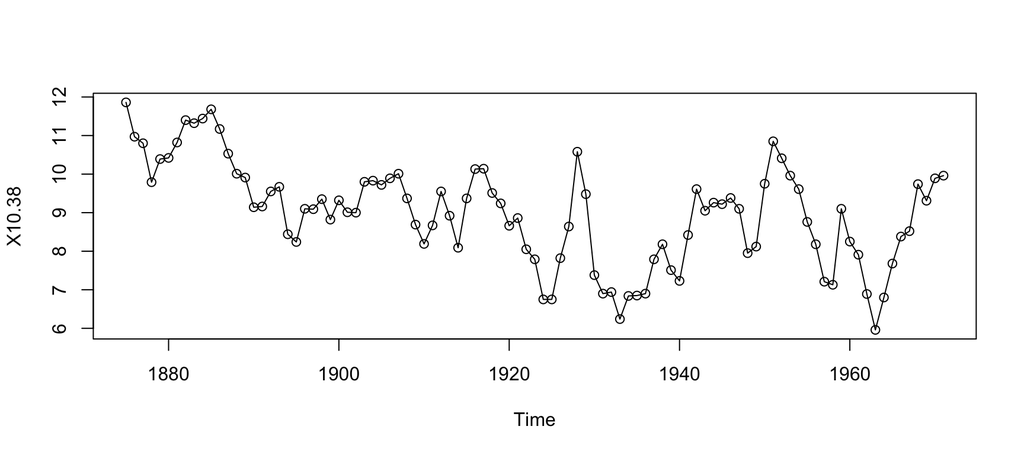

```r
  library(forecast)
  source('https://nmimoto.github.io/R/TS-00.txt')

  D <- read.csv("https://nmimoto.github.io/datasets/lake.csv")
  Lake  <- ts(D, start=1875, freq=1)

  plot(Lake, type="o")
```

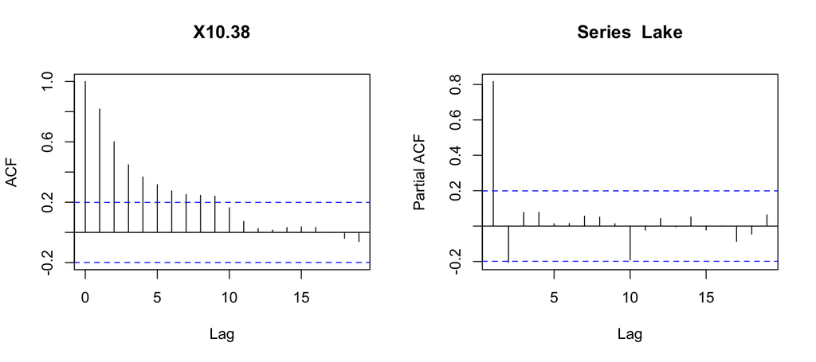

```r
  layout(matrix(c(1,2), 1, 2))
  acf(Lake)
  pacf(Lake)
```

```r
  layout(1)

  Stationarity.tests(Lake)
```

```
##        KPSS  ADF    PP
## p-val: 0.01 0.24 0.025
```

```r
  # find best ARMA(p,q) by AICc
  Fit1 <- auto.arima(Lake, d=0, stepwise=FALSE, approximation=FALSE)

  Fit1
```

```
## Series: Lake
## ARIMA(1,0,1) with non-zero mean
##
## Coefficients:
##          ar1     ma1    mean
##       0.7665  0.3393  9.1290
## s.e.  0.0773  0.1123  0.3861
##
## sigma^2 estimated as 0.4784:  log likelihood=-101.09
## AIC=210.18   AICc=210.62   BIC=220.48
```

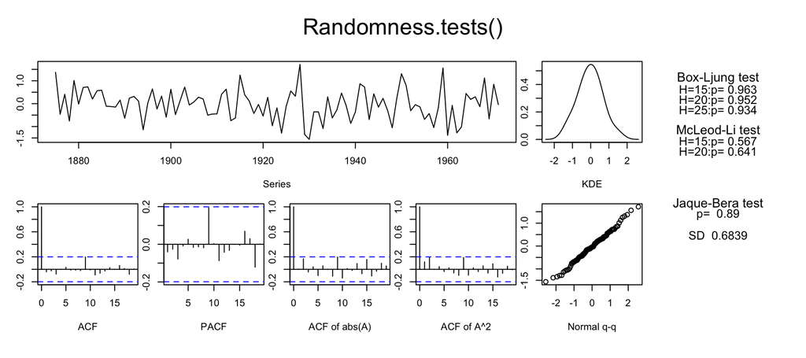

```
##   B-L test H0: the sereis is uncorrelated
##   M-L test H0: the square of the sereis is uncorrelated
##   J-B test H0: the sereis came from Normal distribution
##   SD         : Standard Deviation of the series
```

```
##       BL15  BL20  BL25  ML15  ML20   JB    SD
## [1,] 0.963 0.952 0.934 0.567 0.641 0.89 0.684
```

```r
  Randomness.tests(Fit1$residuals)
```

#### Analysis 1 (direct fit)

```r
  Fit1
```

```
## Series: Lake
## ARIMA(1,0,1) with non-zero mean
##
## Coefficients:
##          ar1     ma1    mean
##       0.7665  0.3393  9.1290
## s.e.  0.0773  0.1123  0.3861
##
## sigma^2 estimated as 0.4784:  log likelihood=-101.09
## AIC=210.18   AICc=210.62   BIC=220.48
```

## b) Forcing Linear Trend

If we choose that the level is going down linearly, we can try to fit a line with ARMA errors.

```r
  Reg2 <- lm(Lake~time(Lake))
  summary(Reg2)
```

```
##
## Call:
## lm(formula = Lake ~ time(Lake))
##
## Residuals:
##      Min       1Q   Median       3Q      Max
## -2.50919 -0.74760 -0.01556  0.75966  2.53409
##
## Coefficients:
##              Estimate Std. Error t value Pr(>|t|)
## (Intercept) 55.278141   7.922614   6.977 4.02e-10 ***
## time(Lake)  -0.024071   0.004119  -5.843 7.16e-08 ***
## ---
## Signif. codes:  0 '***' 0.001 '**' 0.01 '*' 0.05 '.' 0.1 ' ' 1
##
## Residual standard error: 1.136 on 95 degrees of freedom
## Multiple R-squared:  0.2644, Adjusted R-squared:  0.2566
## F-statistic: 34.14 on 1 and 95 DF,  p-value: 7.165e-08
```

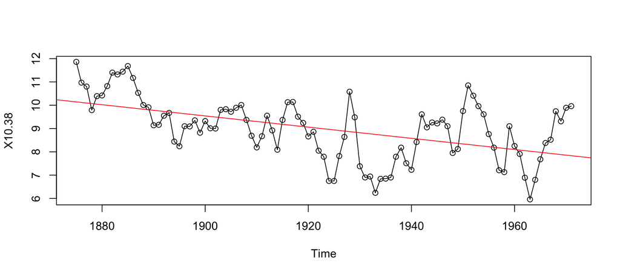

```r
  plot(Lake, type="o")
  abline(Reg2, col="red")         # overlay regression line in red
```

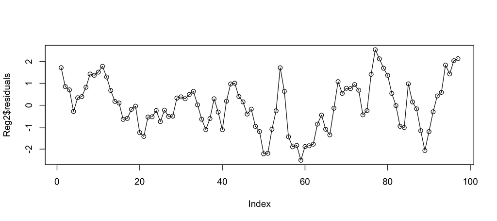

```r
  plot(Reg2$residuals, type="o")            # plot of the residuals from regression
```

```r
  # fit the residuals with ARMA(p,q)
  Fit2 <- auto.arima(Reg2$residuals, d=0, stepwise=FALSE, approximation=FALSE)
  Fit2
```

```
## Series: Reg2$residuals
## ARIMA(1,0,1) with zero mean
##
## Coefficients:
##          ar1     ma1
##       0.6671  0.3827
## s.e.  0.0937  0.1135
##
## sigma^2 estimated as 0.452:  log likelihood=-98.72
## AIC=203.44   AICc=203.7   BIC=211.16
```

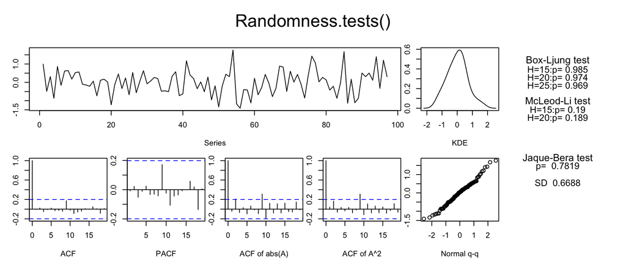

```
##   B-L test H0: the sereis is uncorrelated
##   M-L test H0: the square of the sereis is uncorrelated
##   J-B test H0: the sereis came from Normal distribution
##   SD         : Standard Deviation of the series
```

```
##       BL15  BL20  BL25 ML15  ML20    JB    SD
## [1,] 0.985 0.974 0.969 0.19 0.189 0.782 0.669
```

```r
  Randomness.tests(Fit2$resid)
```

#### Analysis 2 (linear trend)

- Linear trend was fit to $Y_t$, then the residuals were fitted with ARMA(1,1).
- We observe $ Y_t = a+b t + X_t $ $X_t$ is ARMA
- In other words,

$${\large Y_t \hspace{3mm} = \hspace{3mm} a + bt + X_t }$$

$${\large \hspace{20mm} X_t \hspace{3mm} = \hspace{3mm} \phi_1 X_{t-1} + e_t + \theta_1 e_{t-1} }$$

$${\large e_t \sim WN(0, \sigma^2) }$$

```r
  summary(Reg2)
```

```
##
## Call:
## lm(formula = Lake ~ time(Lake))
##
## Residuals:
##      Min       1Q   Median       3Q      Max
## -2.50919 -0.74760 -0.01556  0.75966  2.53409
##
## Coefficients:
##              Estimate Std. Error t value Pr(>|t|)
## (Intercept) 55.278141   7.922614   6.977 4.02e-10 ***
## time(Lake)  -0.024071   0.004119  -5.843 7.16e-08 ***
## ---
## Signif. codes:  0 '***' 0.001 '**' 0.01 '*' 0.05 '.' 0.1 ' ' 1
##
## Residual standard error: 1.136 on 95 degrees of freedom
## Multiple R-squared:  0.2644, Adjusted R-squared:  0.2566
## F-statistic: 34.14 on 1 and 95 DF,  p-value: 7.165e-08
```

```r
  Fit2
```

```
## Series: Reg2$residuals
## ARIMA(1,0,1) with zero mean
##
## Coefficients:
##          ar1     ma1
##       0.6671  0.3827
## s.e.  0.0937  0.1135
##
## sigma^2 estimated as 0.452:  log likelihood=-98.72
## AIC=203.44   AICc=203.7   BIC=211.16
```

Let’s look at the difference between the observations:
$$diff(Y) = Y_t - Y_{t-1} \\ \\$$

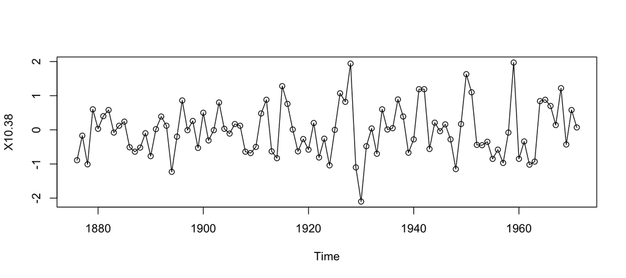

```r
  diff.Y <- diff(Lake)      # takes difference between the observations
  plot(diff.Y, type='o')
```

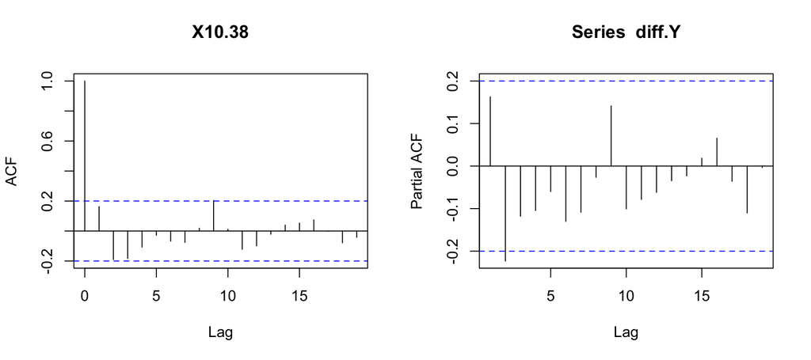

```r
  layout(matrix(1:2, 1, 2))
  acf(diff.Y)
  pacf(diff.Y)
```

```r
  layout(1)

  Stationarity.tests(diff.Y)       # See if diff(Y) is stationary
```

```
##        KPSS  ADF   PP
## p-val:  0.1 0.01 0.01
```

```r
  # Fit the difference of Lake with ARMA
  Fit3 <- auto.arima(diff.Y, d=0, stepwise=FALSE, approximation=FALSE)
  Fit3
```

```
## Series: diff.Y
## ARIMA(1,0,2) with zero mean
##
## Coefficients:
##          ar1      ma1      ma2
##       0.6385  -0.5349  -0.3514
## s.e.  0.1345   0.1445   0.1055
##
## sigma^2 estimated as 0.4812:  log likelihood=-99.88
## AIC=207.76   AICc=208.2   BIC=218.02
```

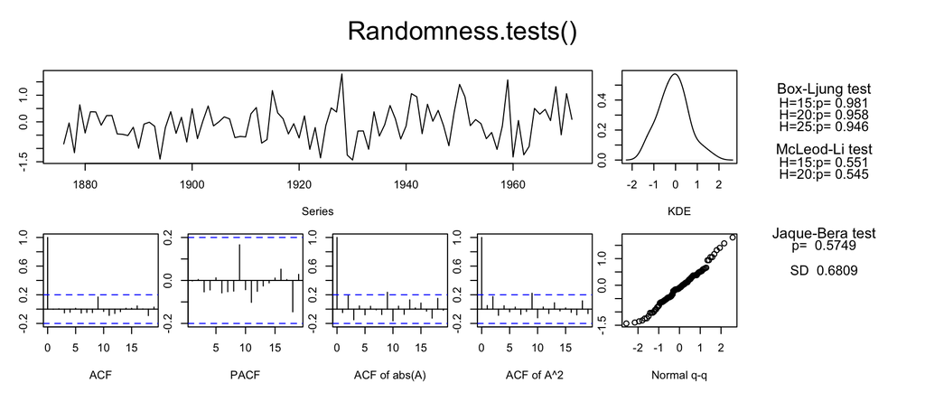

```
##   B-L test H0: the sereis is uncorrelated
##   M-L test H0: the square of the sereis is uncorrelated
##   J-B test H0: the sereis came from Normal distribution
##   SD         : Standard Deviation of the series
```

```
##       BL15  BL20  BL25  ML15  ML20    JB    SD
## [1,] 0.981 0.958 0.946 0.551 0.545 0.575 0.681
```

```r
  Randomness.tests(Fit3$residuals)
```

```r
  #-- Exactly same as below --
  Fit3b <- Arima(Lake, order=c(1,1,2), include.mean=FALSE)
  Fit3b
```

```
## Series: Lake
## ARIMA(1,1,2)
##
## Coefficients:
##          ar1      ma1      ma2
##       0.6385  -0.5349  -0.3514
## s.e.  0.1345   0.1445   0.1055
##
## sigma^2 estimated as 0.4812:  log likelihood=-99.88
## AIC=207.76   AICc=208.2   BIC=218.02
```

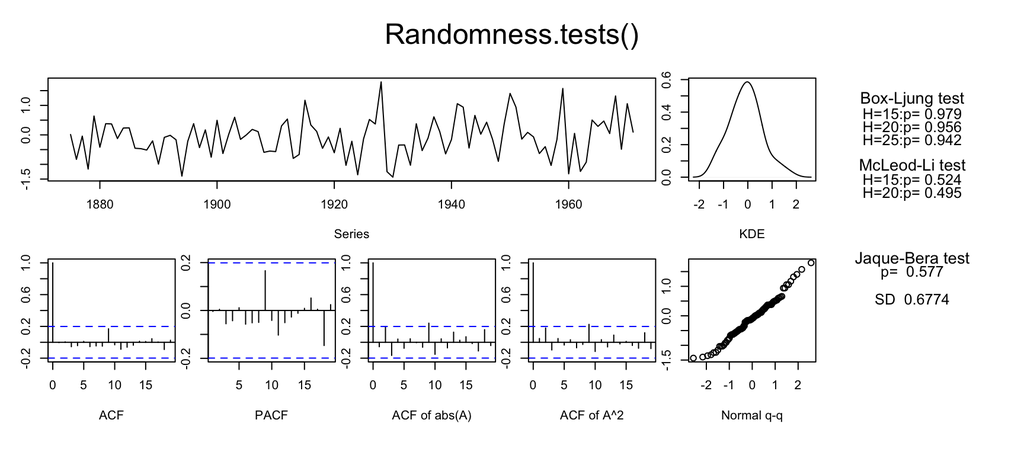

```
##   B-L test H0: the sereis is uncorrelated
##   M-L test H0: the square of the sereis is uncorrelated
##   J-B test H0: the sereis came from Normal distribution
##   SD         : Standard Deviation of the series
```

```
##       BL15  BL20  BL25  ML15  ML20    JB    SD
## [1,] 0.979 0.956 0.942 0.524 0.495 0.577 0.677
```

```r
  Randomness.tests(Fit3b$residuals)
```

#### Analysis 3 (take difference)

```r
  Fit3b
```

```
## Series: Lake
## ARIMA(1,1,2)
##
## Coefficients:
##          ar1      ma1      ma2
##       0.6385  -0.5349  -0.3514
## s.e.  0.1345   0.1445   0.1055
##
## sigma^2 estimated as 0.4812:  log likelihood=-99.88
## AIC=207.76   AICc=208.2   BIC=218.02
```

# Summary

- Three popular test for stationarity is KPSS, ADF, and PP test.
- Tests are availabe in R, can be implemented with below command.

```r
  source('https://nmimoto.github.io/R/TS-00.txt')
  Stationarity.tests(X)
```

- Classical method tries to identify trend, and tries to removeit by polynomial regression.
- Box-Jenkins Method tries to take a difference between today’s data and yesterday’s by applying $\bigtriangledown=(1-B)$ operator.
- applying B-J method will often times stationarize non-stationary time series.
- We can use ARMA($p,q$) model to model the stationarized version of the series.
- If you use $\bigtriangledown$ once, and apply ARMA(1,2), then it is called ARIMA (1,1,2) model.

[TS Class Web Page](https://nmimoto.github.io/477/) – [R resource page](https://nmimoto.github.io/R/)